# Capstone_project

Rohit Agrawal

30/5/2023

# Customer Analysis of Cyclistic Company

This is the case study on a fictional bike-sharing company called Cyclistic (based on real data from Divvy) to answer business questions as the capstone project of my Google Data Analytics Professional Certificate course.

## Data Obtaining

The data can be download in the link below: https://divvy-tripdata.s3.amazonaws.com/index.html

Data was downloaded from the above link for the last one year (April 2022 to March 2023)

To Join the Data and Convert Dates, Extract Days, SQL was used. Data was uploaded in BigQuery and the following SQL query executed.

```
SELECT
  ride_id,
  rideable_type,
  started_at,
  DATE(started_at) AS start_date,
  FORMAT_DATE('%A', started_at) AS start_day_of_week,
  FORMAT_TIME('%r', TIME(started_at)) AS start_time,
  DATE(ended_at) AS end_date,
  FORMAT_DATE('%A', ended_at) AS end_day_of_week,
  FORMAT_TIME('%r', TIME(ended_at)) AS end_time,
  ROUND(TIMESTAMP_DIFF(ended_at, started_at, MINUTE)) AS trip_duration,
  start_station_name,
  start_station_id,
  end_station_name,
  end_station_id,
  start_lat,
  start_lng,
  end_lat,
  end_lng,
  member_casual
FROM (
--Last Years data joined
  SELECT *
  FROM `capstoneproject-396619.cyclist.april22` AS april22
  UNION ALL
  SELECT *
  FROM `capstoneproject-396619.cyclist.may22` AS may22
  UNION ALL
  SELECT *
  FROM `capstoneproject-396619.cyclist.june22` AS june22
  UNION ALL
  SELECT *
  FROM `capstoneproject-396619.cyclist.july22` AS july22
  UNION ALL
  SELECT *
  FROM `capstoneproject-396619.cyclist.aug22` AS aug22
  UNION ALL
  SELECT *
  FROM `capstoneproject-396619.cyclist.sep22` AS sep22
  UNION ALL
  SELECT *
  FROM `capstoneproject-396619.cyclist.oct22` AS oct22
  UNION ALL
  SELECT *
  FROM `capstoneproject-396619.cyclist.nov22` AS nov22
  UNION ALL
  SELECT *
  FROM `capstoneproject-396619.cyclist.dec22` AS dec22
  UNION ALL
  SELECT *
  FROM `capstoneproject-396619.cyclist.jan23` AS jan23
  UNION ALL
  SELECT *
  FROM `capstoneproject-396619.cyclist.feb23` AS feb23
  UNION ALL
  SELECT *
  FROM `capstoneproject-396619.cyclist.mar23` AS mar23
  WHERE
    ROUND(TIMESTAMP_DIFF(ended_at, started_at, MINUTE)) > 0
    --Filtered out any trips with a negative or zero (0) minute duration
) AS cyclist2223;
```

The downloaded data was then loaded in R for further Analysis.

### Load packages

```r
library(tidyverse)
```

```r
library(lubridate)
library(dplyr)
library(ggplot2)
library(readr)
```

### Import Data

```r
data = read.csv("C:\\Users\\dell\\Desktop\\Cyclist\\cyclist.csv")
```

### Data Exploration

```r
glimpse(data)
```

```
## Rows: 5,794,643
## Columns: 20
## $ X                  <int> 0, 1, 2, 3, 4, 5, 6, 7, 8, 9, 10, 11, 12, 13, 14, 1…
## $ ride_id            <chr> "E04A2BED58F02685", "3DB178DA1A9663D2", "BEC44E7361…
## $ rideable_type      <chr> "docked_bike", "docked_bike", "docked_bike", "class…
## $ started_at         <chr> "2022-11-25 13:04:18+00:00", "2022-11-04 16:04:27+0…
## $ start_date         <chr> "2022-11-25", "2022-11-04", "2022-11-04", "2022-11-…
## $ start_day_of_week  <chr> "Friday", "Friday", "Friday", "Friday", "Friday", "…
## $ start_time         <chr> "01:04:18 PM", "04:04:27 PM", "02:27:44 PM", "09:30…
## $ end_date           <chr> "2022-11-25", "2022-11-04", "2022-11-04", "2022-11-…
## $ end_day_of_week    <chr> "Friday", "Friday", "Friday", "Friday", "Friday", "…
## $ end_time           <chr> "01:20:39 PM", "04:13:54 PM", "02:34:37 PM", "09:33…
## $ trip_duration      <dbl> 16, 9, 6, 2, 8, 25, 6, 10, 2, 6, 35, 19, 11, 21, 11…
## $ start_station_name <chr> "Green St & Washington Blvd", "Rush St & Cedar St",…
## $ start_station_id   <chr> "13053", "KA1504000133", "15648", "13135", "TA13080…
## $ end_station_name   <chr> "Millennium Park", "Mies van der Rohe Way & Chicago…
## $ end_station_id     <chr> "13008", "13338", "15651", "13164", "21544", "TA130…
## $ start_lat          <dbl> 41.88318, 41.90231, 41.92463, 41.85756, 41.90672, 4…
## $ start_lng          <dbl> -87.64872, -87.62769, -87.68931, -87.66154, -87.634…
## $ end_lat            <dbl> 41.88103, 41.89695, 41.91751, 41.85817, 41.89662, 4…
## $ end_lng            <dbl> -87.62408, -87.62176, -87.70181, -87.65650, -87.628…
## $ member_casual      <chr> "casual", "casual", "casual", "member", "casual", "…
```

### Descriptive Analysis

```r
count(data, rideable_type)
```

| rideable_type | n |
| --- | --- |
| classic_bike | 2638021 |
| docked_bike | 173723 |
| electric_bike | 2982899 |

```r
mean(data$trip_duration)
```

```
## [1] 18.51925
```

```r
range(data$trip_duration)
```

```
## [1] -10353  41387
```

Few Durations are in negative, Might be some error. Take absolute values of them.

```r
data$trip_duration <- abs(data$trip_duration)
range(data$trip_duration)
```

```
## [1]     0 41387
```

```r
mode_day = function(){
  return(sort(-table(data$start_day_of_week))[1])
}
mode_day()
```

```
## Saturday
##  -922766
```

```r
member_counts <- count(data, member_casual)
```

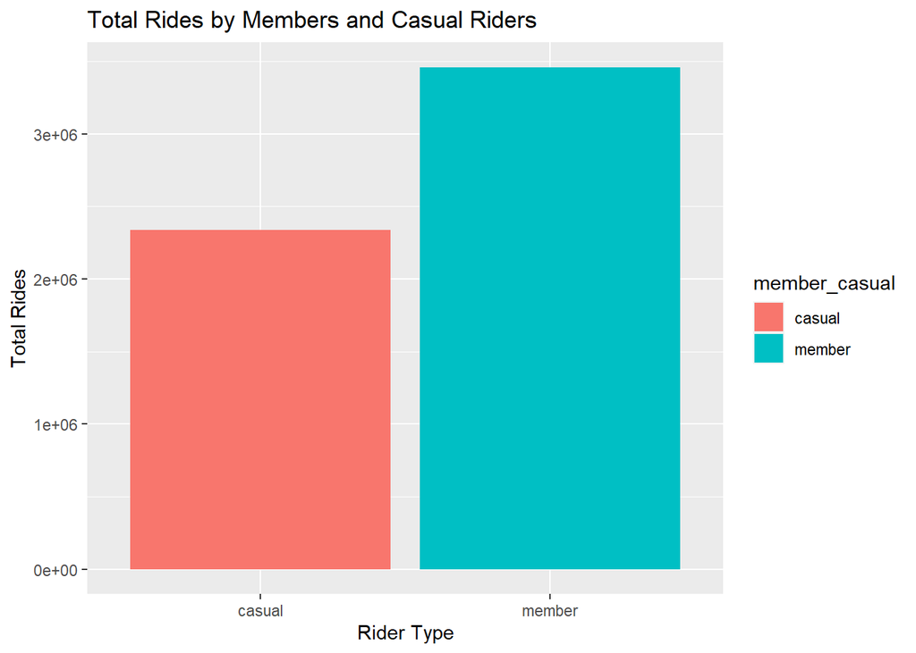

```r
ggplot(member_counts, aes(x = member_casual, y = n, fill = member_casual)) +
  geom_bar(stat = "identity")+
  labs(title = "Total Rides by Members and Casual Riders", x = "Rider Type", y = "Total Rides")
```

Let’s Analyse the Total rides by Days

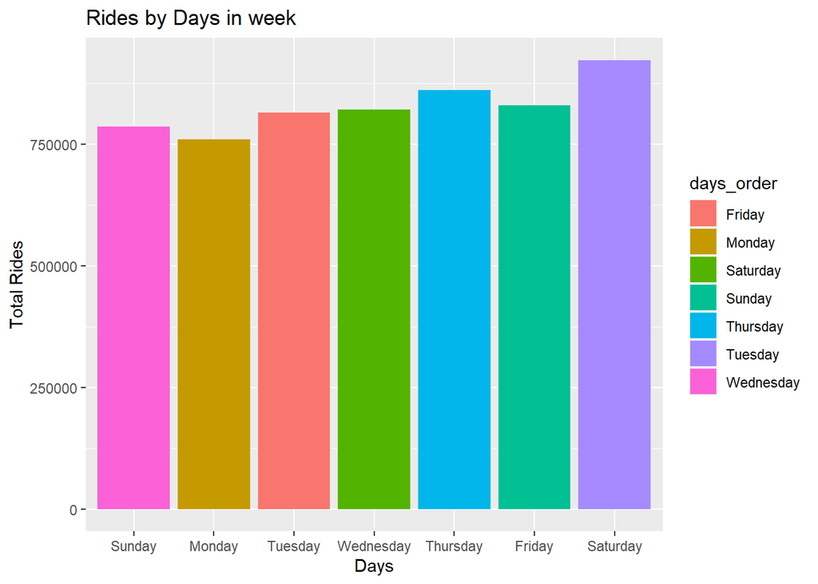

```r
days_counts <- count(data, start_day_of_week)
days_order <- c("Sunday", "Monday", "Tuesday", "Wednesday", "Thursday", "Friday", "Saturday")

ggplot(days_counts, aes(x = factor(start_day_of_week, days_order), y = n, fill = days_order)) +
  geom_bar(stat = "identity")+
  labs(title = "Rides by Days in week", x = "Days", y = "Total Rides")
```

Break Down each day by Customer Type.

```r
rides_by_day_member <- data %>%
  group_by(start_day_of_week, member_casual) %>%
  summarise(average_rides = n() / n_distinct(start_date)) %>%
  ungroup() %>%
  arrange(-average_rides)
print(rides_by_day_member)
```

```
## # A tibble: 14 × 3
##    start_day_of_week member_casual average_rides
##    <chr>             <chr>                 <dbl>
##  1 Thursday          member               10574.
##  2 Wednesday         member               10479.
##  3 Tuesday           member               10443.
##  4 Monday            member                9301.
##  5 Friday            member                9222.
##  6 Saturday          casual                9062.
##  7 Saturday          member                8683.
##  8 Sunday            member                7641.
##  9 Sunday            casual                7485.
## 10 Friday            casual                6429.
## 11 Thursday          casual                5989.
## 12 Wednesday         casual                5314.
## 13 Monday            casual                5298.
## 14 Tuesday           casual                5213.
```

See how many rides for days of week by customer

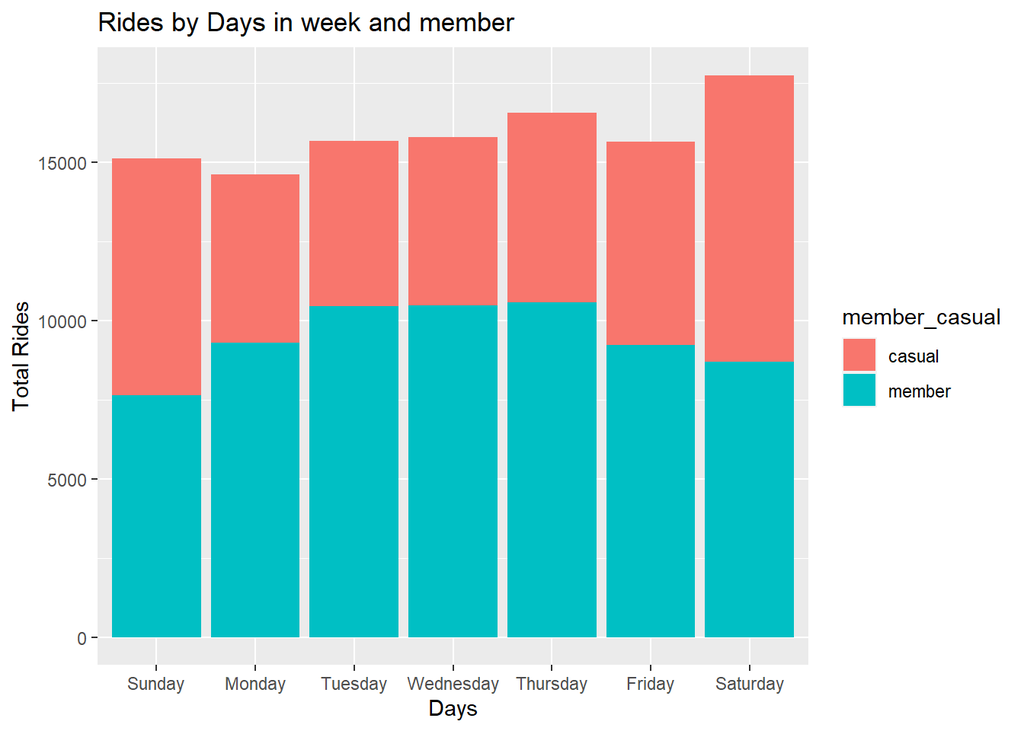

```r
ggplot(rides_by_day_member, aes(x = factor(start_day_of_week, days_order), y = average_rides, fill = member_casual)) +
  geom_bar(stat = "identity")+
  labs(title = "Rides by Days in week and member", x = "Days", y = "Total Rides")
```

We can see that on Saturday and Sundays, the number of rides by casual rides are of higer proportion wrt other days.

Analying how customer takes rides on Different times of each days.

```r
data$start_time <- as.POSIXct(data$start_time, format = "%I:%M:%S %p")
ride_by_hours_days <- data %>%
  mutate(start_hour = hour(start_time),
         start_day_of_week = factor(start_day_of_week,days_order)) %>%
  group_by(member_casual, start_hour, start_day_of_week) %>%
  summarise(total_rides = n()) %>%
  arrange(member_casual, start_hour, start_day_of_week)
ride_by_hours_days
```

| member_casual | start_hour | start_day_of_week | total_rides |
| --- | --- | --- | --- |
| casual | 0 | Sunday | 14957 |
| casual | 0 | Monday | 4321 |
| casual | 0 | Tuesday | 3037 |
| casual | 0 | Wednesday | 3104 |
| casual | 0 | Thursday | 3864 |
| casual | 0 | Friday | 5572 |
| casual | 0 | Saturday | 11797 |
| casual | 1 | Sunday | 9990 |
| casual | 1 | Monday | 2401 |
| casual | 1 | Tuesday | 1620 |

[output cut: 326 more lines]

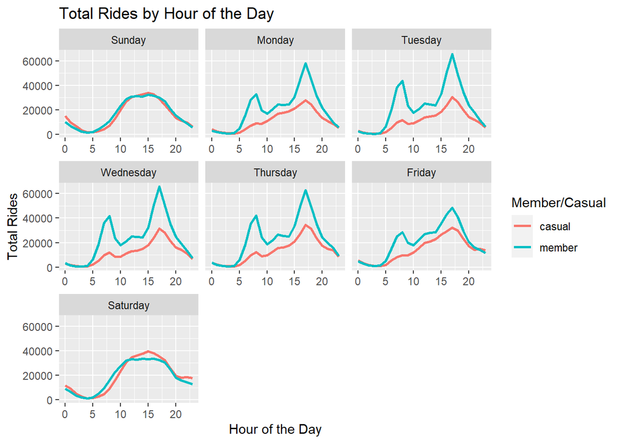

```r
ggplot(ride_by_hours_days, aes(x = start_hour, y = total_rides, color = member_casual)) +
  geom_line(linewidth = 1) +
  facet_wrap(~ start_day_of_week, ncol = 3, scales = "free_x") +
  labs(x = "Hour of the Day", y = "Total Rides", color = "Member/Casual") +
  ggtitle("Total Rides by Hour of the Day")
```

Here and interesting thing comes up. During weekdays, there two modes are present on each working day. That might be due to the working class people who use bikes to commute to and from work.

On Sundays and Saturdays, similar behaviour is seem by members and non members.

Let’s see Average duration of rides.

```r
rides_by_duration_member <- data %>%
  group_by(member_casual) %>%
  summarise(average_duration = sum(trip_duration) / n()) %>%
  ungroup() %>%
  arrange(-average_duration)
rides_by_duration_member
```

| member_casual | average_duration |
| --- | --- |
| casual | 28.13642 |
| member | 12.03355 |

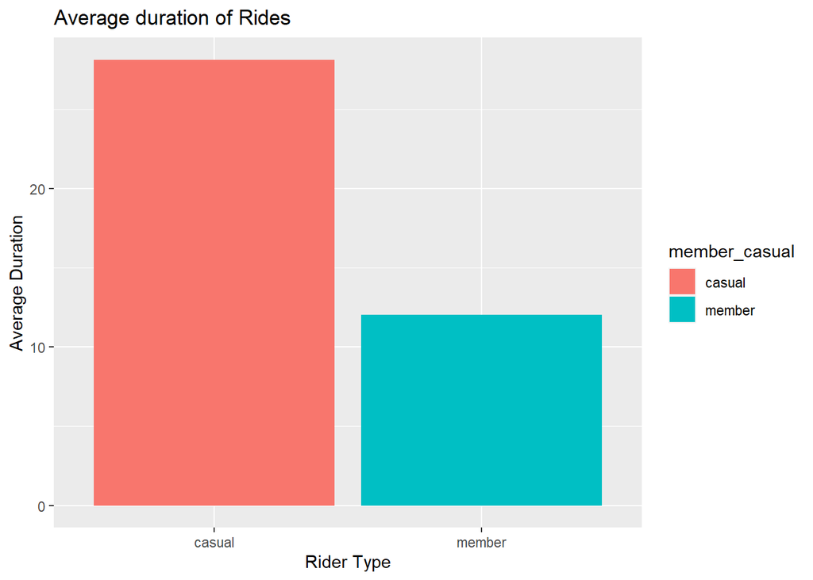

```r
ggplot(rides_by_duration_member, aes(x = member_casual, y = average_duration, fill = member_casual)) +
  geom_bar(stat = "identity")+
  labs(title = "Average duration of Rides", x = "Rider Type", y = "Average Duration")
```

Although the number of rides by casual riders were less but the average duration of the rides are more than that of members.

## Conclusions and Recommendations.

1. Members dominate Cyclistic’s Rides number and they ride significantly more than casual riders.
2. Casual Riders have more duration of average rides. This might be due to the tendeny of liesure (enjoy the ride) by slow pace.
3. Weekend Membership Option can be great option those riders who ride only on weekend.